# 1.1. Methanol price analysis

## 1.1. Methanol price analysis

From a wide range of factors that are used in the company forecasting system, it is possible to select three that have the highest correlation with the price of methanol.

- The first is the price of gas, with a correlation of 0.906. The factor demonstrates a strong relationship with the price of methanol and is present in all models, regardless of the estimation interval.
- The second factor is the price of oil, with a correlation of 0.805. The factor also demonstrates a strong relationship with the price of methanol and is present in all models, regardless of the estimation interval.
- The third factor is the price of Australian coal, which correlates with 0.516. The factor begins to significantly influence after the 2008-2009 crisis.

An analysis of the directions of the relationship between the variables shows that the most correct models are obtained when using data from 2012.

[figure not shown]

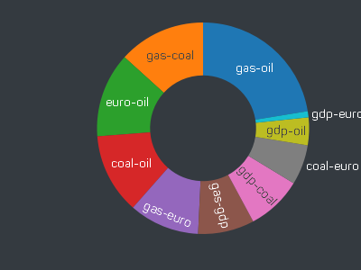

[figure not shown]

[figure not shown]

- For almost 9 years since 2012, there have been two periods of price increases and two periods of price decreases. All these movements can be explained using a three-factor model. At the same time, model estimates are smoother, and real data are more volatile.
- In the process of modeling, the possibility of delayed influence of factors was taken into account. The analysis showed that the best quality model is obtained using gas prices with a lag of one month.
- The final equation of the methanol price model: Methanol price (`$`) = 61.2 + 0.624 * Brent price (`$`) + 27.32 * Gas price (`$`) + 0.628 * Coal price (`$`)
- The R-square index of the model is 0.830.
- The model does not use the autoregressive component, since the analysis showed that when using it, forecasts for 1-3 months are improved, but the accuracy of forecasts for periods of more than 3 months decreases due to the underestimated influence of other factors.

## Methanol forecast

| year | oil | euro | coal | gdp | gas | methanol | gdp_less_1 | model | err |
| --- | --- | --- | --- | --- | --- | --- | --- | --- | --- |
| 2012 | 109.6765 | 1.3110953849636 | 92.88 | 1.13330889604595 | 10.5625 | 431.716616666667 | 0 | 476.6155863915 | 0.10400102287353 |
| 2013 | 110.674 | 1.36951377232217 | 84.3375 | 2.51986222635993 | 11.2866666666667 | 537.705316666667 | 0 | 491.649189447334 | 0.0856530999262626 |
| 2014 | 62.33 | 1.23279999081493 | 62.44 | 3.09612278152956 | 8.3625 | 375.1706875 | 0 | 367.82873253 | 0.0195696391392517 |
| 2015 | 37.72 | 1.08697826086957 | 52.1275 | 3.00522023514886 | 5.25 | 236.62155 | 0 | 260.96036382 | 0.102859666923828 |
| 2016 | 54.07 | 1.05502608695652 | 86.32 | 2.99636346938427 | 5.3625 | 316.81850625 | 0 | 295.73664447 | 0.066542393717886 |
| 2017 | 64.21 | 1.18380909090909 | 102.155 | 3.36208676787324 | 7.46333333333333 | 367.56368125 | 0 | 369.410512976667 | 0.00502452179275692 |
| 2018 | 56.46 | 1.13835909090909 | 101.37 | 2.6737969 | 8.01666666666667 | 326.58625 | 0 | 379.195615593333 | 0.161088734119496 |
| 2019 | 65.85 | 1.11061428571429 | 66.18 | 2.4566793 | 4.86 | 224.708083333333 | 0 | 276.69853255 | 0.231368842835725 |
| 2020 | 41.09 | 1.18105652173913 | 54.6 | -2 | 3.74333333333333 |  | -2 | 223.460252056667 |  |
| 2021 | 45 | 1.2 | 63.69 | 2 | 3.66448886194379 |  | 0 | 229.462141119045 |  |
| 2022 | 45 | 1.22 | 69.6080065625 | 2 | 4.88572420088728 |  | 0 | 266.543925775684 |  |
| 2023 | 45 | 1.24 | 74.27375 | 2 | 5.05664274751648 |  | 0 | 274.146581578167 |  |
| 2024 | 45 | 1.24 | 75.6 | 2 | 5.29190037015231 |  | 0 | 281.40706346754 |  |
| 2025 | 45.99 | 1.24 | 75.6 | 2 | 4.22940806641501 |  | 0 | 253.000576098195 |  |
| 2026 | 47.00178 | 1.24 | 75.6 | 2 | 4.32245504387614 |  | 0 | 256.173825740355 |  |
| 2027 | 48.03581916 | 1.24 | 75.6 | 2 | 4.41754905484142 |  | 0 | 259.416886874643 |  |
| 2028 | 49.09260718152 | 1.24 | 75.6 | 2 | 4.51473513404793 |  | 0 | 262.731295353885 |  |
| 2029 | 50.1726445395134 | 1.24 | 75.6 | 2 | 4.61405930699698 |  | 0 | 266.11862081967 |  |
| 2030 | 51.2764427193827 | 1.24 | 75.6 | 2 | 4.71556861175092 |  | 0 | 269.580467445703 |  |
| 2031 | 52.4045244592092 | 1.24 | 75.6 | 2 | 4.81931112120944 |  | 0 | 273.118474697509 |  |
| 2032 | 53.5574239973118 | 1.24 | 75.6 | 2 | 4.92533596587605 |  | 0 | 276.734318108854 |  |
| 2033 | 54.7356873252526 | 1.24 | 75.6 | 2 | 5.03369335712532 |  | 0 | 280.429710075249 |  |
| 2034 | 55.9398724464082 | 1.24 | 75.6 | 2 | 5.14443461098208 |  | 0 | 284.206400664904 |  |
| 2035 | 57.1705496402292 | 1.24 | 75.6 | 2 | 5.25761217242368 |  | 0 | 288.066178447532 |  |